# Exploring zonation options

Robyn Seymour-Jones

26/11/2020

## 1. Introduction

I want to define diatom assemblage zones within the record so that it is easier to describe and compare with other sequences. This sort of thing is usually done by a constrained cluster analysis whereby stratigraphically adjacent samples are grouped together based on the similarities of their diatom assemblage. The specific cluster analysis chosen is the **Constrained Incremental Sum of Squares (CONISS)** method as outlined by Grimm (1987).

### The CONISS algorithm

First, a matrix of dissimilarities between samples is computed. The CONISS algorithm then computes a statistic known as the *sum of squares** between each pair of adjacent samples (each sample can be considered a cluster of just one sample at this stage). The pair with the smallest sum of squares is joined into a cluster and then the sum of squares is recalculated for all samples with these newly joined samples recieving one sum of squares value for their cluster. The clusters with the smallest sum of squares is joined and the sum of squares recalulated. This process continues, clustering samples into successively larger groups (it is therefore an agglomerative technique).

*The sum of squares is the squared difference between the value of a taxon in one sample of a cluster divided by the average value of that taxon across all samples in that cluster, which then summed for each taxon, which is then summed for each sample in the cluster.

### Decisions to make

1. I need to decide what to do about one particular outlier sample. If it is not good enough for the cluster analysis, I also need to decide if I am going to remove it from all of the other analyses completely.
2. Do I perform the cluster analysis with *P. ocellata* split into their size classes as they will be displayed on the stratigraphical diagram or with them just grouped as one taxon?
3. Should I perform the cluster analysis on all of the taxa that were counted or on only the abundant taxa?
4. If I perform the cluster analysis on only the abundant taxa, should I choose those present at 5 % or above in at least one sample as is done by Gordon and Birks (1972) or 4 % to keep this analysis consistent with the other results on my stratigraphic diagram?
5. If I perform the cluster analysis on only the abundant taxa, should I base the percentage abundance calculation on all taxa or only the abundant taxa? The latter is what is done by Gordon and Birks (1972).

### Purpose of this document

This document will display the results of various different cluster analyses to help me answer the above questions. It also puts them all in one place for easy reference at a later date.

### A twist in the tale

To make matters even more complicated, I first performed a cluster analysis on the diatom results using the Tilia program (Grimm, 2011). I have described the results according to the zones that it produced. To avoid a massive amount of repeat work, the final zonation resulting from the cluster analysis needs to be as close as possible to the original cluster analysis results I obtained in Tilia.

## 2. Set up

The data are imported with the [manipulate script](https://github.com/robynfsj/phd-ioannina-long-record/blob/master/scripts/02-manipulate.R). I will need the data frames in the **taxa** list. I will also need the depths data frame in the **imported** list.

```r
library(rioja) # chclust()
library(ggdendro) # dendro_data()
library(ggplot2)
library(patchwork)
source("scripts/02-manipulate.R")
```

## 3. Data preparation method

The data need to be prepared correctly prior to the cluster analysis. The following steps are required.

1. Samples containing no diatoms are removed.
2. The analysis needs to be performed on relative abundance data, not on raw counts. These must first be calculated and are done so differently in the analyses in this document as I try to figure out if the proportion is out of all diatoms counted or only out of abundant taxa. Although I use percentage relative abundance for my other analyses and displaying results, the Tilia program performs the cluster analysis on relative proportions out of 1.0 so the percentage relative abundances are divided by 100 to transform them to unit proportions (i.e. out of 1.0). This step is only necessary to keep the result the same as the one I obtained from Tilia. If this step is not done, the resulting dendrogram looks the same except the x-axis values are just 100 times larger.
3. The data are then square-root transformed. This step is necessary as the record is dominated by one taxon (P. ocellata, particularly valves ≤20 µm). Square-root transforming ensures the less abundant taxa play a more important role in the cluster analysis than they would otherwise. My supervisor says this is what you must always do and reading around the literature it does seem to be standard practice for diatom abundance data.
4. The squared Euclidean distance between samples is then calculated. This dissimilarity index is used because it is the one that the Tilia program uses and once again I am trying to match the results I previously obtained. Grimm (1987) says that the combination of square-root transforming and then calculating the squared Euclidean distance has proved “particularly satisfactory” for abundance data. As researchers have been using Tilia for years to define zones in ecological records, it is therefore also the distance that other researchers have been using for the same purpose as me.

## 4. Addressing my questions

### My original Tilia analysis

This reproduces the cluster analysis that I performed in Tilia and plots the results as a dendrogram.

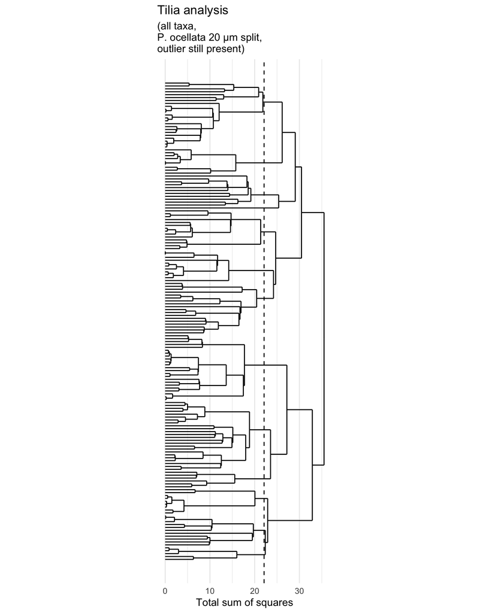

```r
# Prepare data
dist_matrix_tilia <- taxa$rel_ab_split_20µm %>%
  mutate(
    depth = imported$depths$depth,
    sample_no = NULL
  ) %>%
  column_to_rownames("depth") %>%
  filter(., rowSums(.) > 0) %>%
  `/`(100) %>%
  sqrt() %>%
  designdist(., method = "A+B-2*J", terms = "quadratic")

# Run cluster analysis
clusters_tilia <- chclust(dist_matrix_tilia, method = "coniss")

# Plot
ddata_tilia <- dendro_data(clusters_tilia, type = "rectangle")

tilia <- ggplot(segment(ddata_tilia)) +
  geom_segment(aes(x = x, y = y, xend = xend, yend = yend)) +
  coord_flip() +
  scale_x_reverse(breaks = NULL,
                  labels = NULL) +
  labs(x = "",
       y = "Total sum of squares") +
  theme_minimal() +
  theme(aspect.ratio = 3) +
  geom_hline(yintercept = 22.1,
             linetype = 2)

tilia +
  labs(
    title = "Tilia analysis",
    subtitle = "(all taxa,\nP. ocellata 20 µm split,\noutlier still present)"
    )
```

#### Reading the dendrogram

Each sample of the core is represented on the dendrogram. It is easy to identify each sample — each one is a horizontal line on the dendrogram originating from the left hand side of the plot. Each sample joins another adjacent cluster or sample at a certain total sum of squares value along the x-axis. The smaller the total sum of squares at which the clusters/samples join together, the more similar they are. Note that for the purposes of this document, the samples just appear in sequential order and are not plotted by depth. This is proving very difficult to do so is something I will work on next.

By placing the vertical dashed line through the dendrogram, each horizonal line that it crosses is designated as a zone. All the samples on the left that eventually cluster into that horizontal line are part of that zone. In this example, 13 zones have been created. When I did this originally, I ignored one zone as it contained only one sample and I was thinking this might be an outlier anyway. I also created some subzones.

### Decision 1: Should I remove the outlier sample?

Several samples in my record were so badly preserved that no diatoms were counted. There were a handful of samples adjacent to these where preservation was still poor but enough diatoms were present to count around 100 diatom valves. Of these samples, all except one had a similar assemblage to those stratigraphically adjacent to them so I deemed that although their preservation was poor, they were probably representative of their environment. However, this one sample in MIS 7d is very different to the others adjacent to it. It has the lowest planktonic abundance of the whole record, whilst this might be what was actually living in the lake at the time, it is also a possibility that the preservation is so poor that it has skewed the assemblage to favour valves that preserve better than others. I should probably remove it. But if I do, should I remove the other samples where I was only able to count 100 diatoms or is my argument that they are similar to their adjacent samples strong enough to keep them in?

#### Compare dendrograms

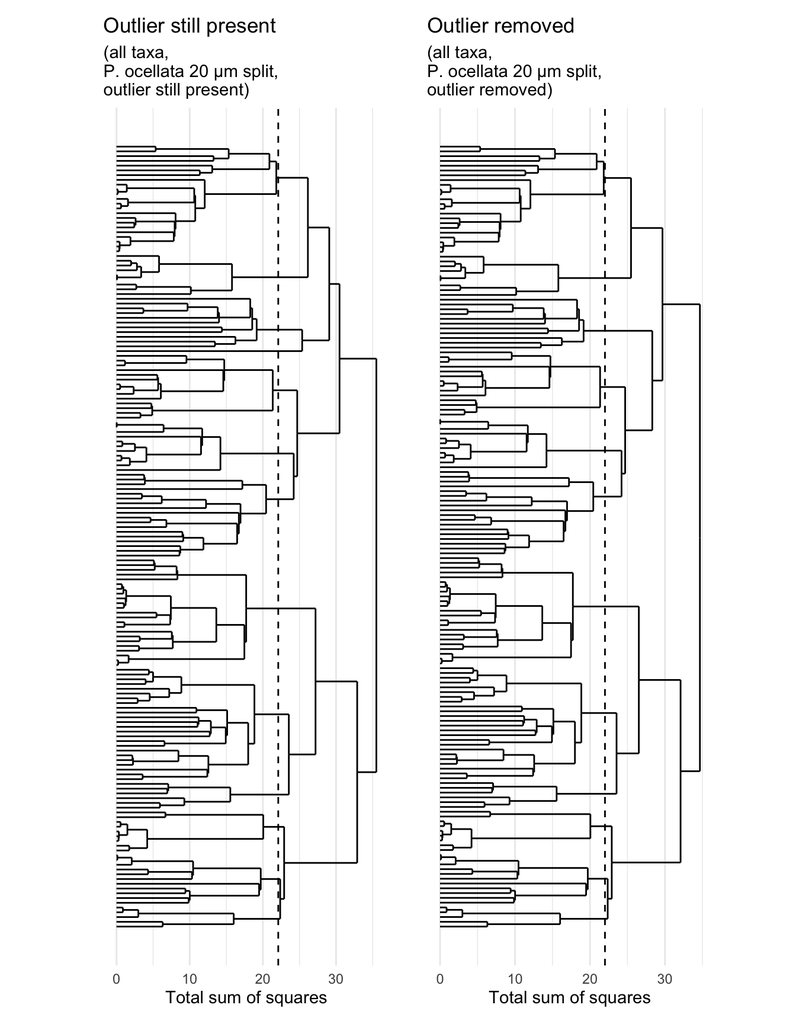

```r
# With outlier removed
# ————————————————————

# Prepare data
dist_matrix_no_outlier <- taxa$rel_ab_split_20µm %>%
  mutate(
    depth = imported$depths$depth,
    sample_no = NULL
  ) %>%
  column_to_rownames("depth") %>%
  filter(., rowSums(.) > 0) %>%
  `/`(100) %>%
  sqrt() %>%
  rownames_to_column("depth") %>%
  mutate(depth = as.numeric(depth)) %>%
  slice(., -44) %>%
  column_to_rownames("depth") %>%
  designdist(., method = "A+B-2*J", terms = "quadratic")

# Run cluster analysis
clusters_no_outlier <- chclust(dist_matrix_no_outlier, method = "coniss")

# Create plots
ddata_no_outlier <- dendro_data(clusters_no_outlier, type = "rectangle")
no_outlier <- ggplot(segment(ddata_no_outlier)) +
  geom_segment(aes(x = x, y = y, xend = xend, yend = yend)) +
  coord_flip() +
  scale_x_reverse(breaks = NULL,
                  labels = NULL) +
  labs(x = "",
       y = "Total sum of squares") +
  theme_minimal() +
  theme(aspect.ratio = 3) +
  geom_hline(yintercept = 22,
             linetype = 2)


# Plot dendrograms
# ————————————————
tilia +
  labs(
    title = "Outlier still present",
    subtitle = "(all taxa,\nP. ocellata 20 µm split,\noutlier still present)"
  ) +
no_outlier +
  labs(
    title = "Outlier removed",
    subtitle = "(all taxa,\nP. ocellata 20 µm split,\noutlier removed)"
  )
```

Removing the outlier has little effect on the rest of the dendrogram. I grouped the outlier in with the samples above it in my original description so removing the outlier in this situation would be best as it would mean I wouldn’t have to explain why I have grouped this single sample that should be in its own group in with other samples.

#### Compare broken stick

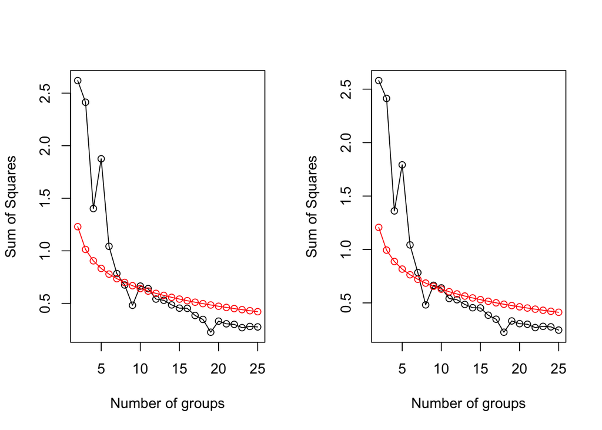

```r
par(mfrow = c(1, 2))
bstick(clusters_tilia, ng = 25)
bstick(clusters_no_outlier, ng = 25)
```

The broken stick results are annoying as the observed sum of squares fluctuate above and below the model at precisely the point at which I want them to go below the model for the rest of the plot. Removing the outlier removes the seventh point and shifts the remaining points to the left. This makes sense because the outlier sample goes into a group on its own on the seventh split from the right of the Tilia dendrogram with a total sum of squares of around 25.5. The broken stick with the outlier suggests there should be 7 or 11 zones depending on when you think the observed sum of squares falls below the model. The broken stick without the outlier suggests there should be 7 or 10 zones.

#### *Decision: remove outlier*

### Decision 2: Should I split *P. ocellata* for the cluster analysis?

Due to the way the Tilia software works, I perfomed the cluster analysis in that program on *P. ocellata* split into the 20 µm size classes (≤20 µm, >20 µm and unclassifiable). The program required me to input the data with them split as the primary function of that program is to plot the stratigraphic diagram. However, thinking about this, I don’t think it is a good idea to do the cluster analysis with them split in this way. Mainly because it creates this artificial group of unclassifiable valves (valves that were too dissolved or obscured by sediment/other valves to assign a size class too). This artificial group could end up influencing where the zone boundaries go and I wouldn’t want that at all. So here I am just checking that performing the cluster analysis with the valves grouped won’t affect the zone boundaries too much and cause me to rewrite my results section.

#### Compare dendrograms

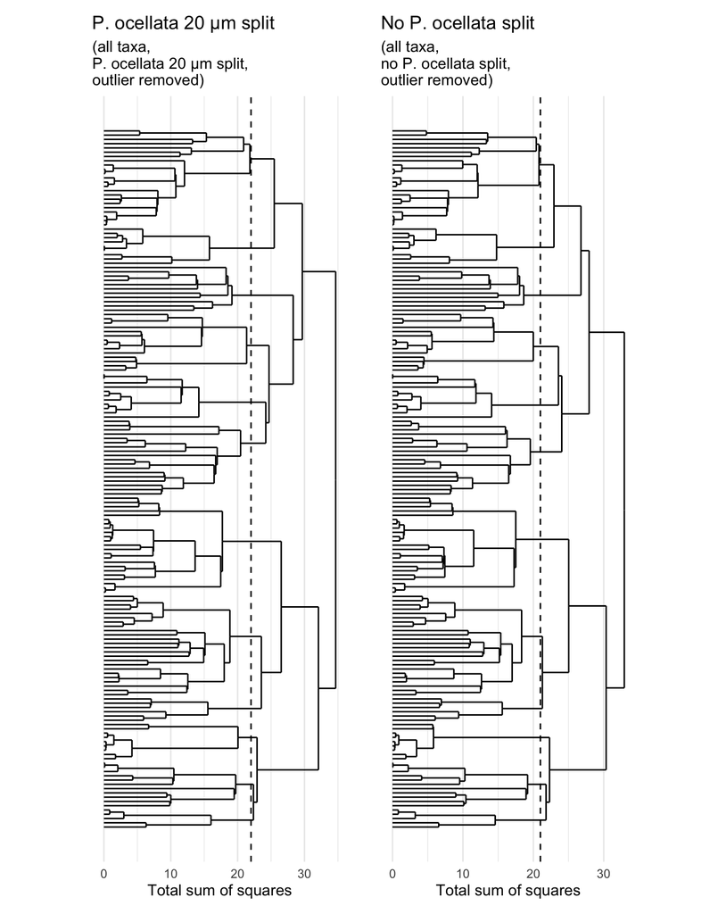

```r
# With no P. ocellata split
# —————————————————————————————

# Prepare data
dist_matrix_no_split <- taxa$rel_ab %>%
  mutate(
    depth = imported$depths$depth,
    sample_no = NULL
  ) %>%
  column_to_rownames("depth") %>%
  filter(., rowSums(.) > 0) %>%
  `/`(100) %>%
  sqrt() %>%
  rownames_to_column("depth") %>%
  mutate(depth = as.numeric(depth)) %>%
  slice(., -44) %>%
  column_to_rownames("depth") %>%
  designdist(., method = "A+B-2*J", terms = "quadratic")

# Run cluster analysis
clusters_no_split <- chclust(dist_matrix_no_split, method = "coniss")

# Create plots
ddata_no_split <- dendro_data(clusters_no_split, type = "rectangle")
no_split <- ggplot(segment(ddata_no_split)) +
  geom_segment(aes(x = x, y = y, xend = xend, yend = yend)) +
  coord_flip() +
  scale_x_reverse(breaks = NULL,
                  labels = NULL) +
  labs(x = "",
       y = "Total sum of squares") +
  theme_minimal() +
  theme(aspect.ratio = 3) +
  geom_hline(yintercept = 21,
             linetype = 2)


# Plot dendrograms
# ————————————————
no_outlier +
  labs(
    title = "P. ocellata 20 µm split",
    subtitle = "(all taxa,\nP. ocellata 20 µm split,\noutlier removed)"
  ) +
no_split +
  labs(
    title = "No P. ocellata split",
    subtitle = "(all taxa,\nno P. ocellata split,\noutlier removed)"
    )
```

If I move the vertical line at which I am splitting the dendrogram into zones (from total sum of square of 22 to 21), I can create the same zones as before. The relationships between the zones change slightly but that doesn’t matter for what I am trying to do.

#### Compare broken stick

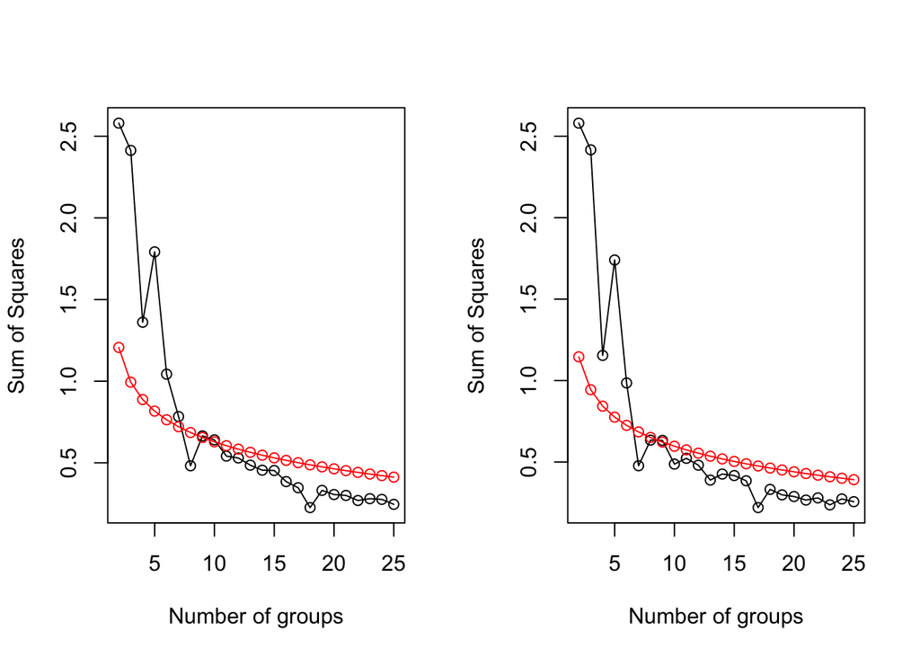

```r
par(mfrow = c(1, 2))
bstick(clusters_no_outlier, ng = 25)
bstick(clusters_no_split, ng = 25)
```

It does have some effect on the number of zones that the broken stick model suggests I should have. It suggests only 6 or 9 zones. Going on this information, I probably split my record into too many zones when I did it with Tilia.

#### *Decision: do not split P. ocellata*

### Decision 3: Should the cluster analysis be performed on all or abundant taxa?

Gordon and Birks (1972) suggest that the cluster analysis should only be run on taxa present at ≥5 % in at least one sample as the low abundance taxa “are of little numerical importance in biostratigraphy”. Grimm (1987) eliminated those present at “<3 % at every level”, noting that the “elimitation of rare taxa has little effect on the analysis”. In the paper about determining the number of zones to split a record into, Bennett (1996) also uses only the abundant taxa present at >5 % in at least one sample, stating that “Birks & Berglund (1979) and Birks (1986) recommended that data sets for numerical zonation should only contain those taxa with proportions that exceed 5 %”. Bennett (1996) then goes on to assess the effect of lowering and increasing the threshold for taxa inclusion. Lowering the threshold slight increases the number of zones recognised, raising the threshold to 10 % or 20 % changes the location of zone markers to positions that suit the remaining taxa. It’s interesting to note here that using the CONISS method, the analysis in Bennett (1996) identified 6 zones with the threshold set at 0-5 %, 1 %, 2 % or 5 %, and identified 5 zones with the threshold set at 10 % or 20 % — a difference of only one zone.

Investigating those references provided by Bennett (1996), Birks (1986, pg 757) gives the following reason for including on abundance taxa:

> “Experience with many data sets has shown that pollen types with values less than 5 % are of minor *numerical* importance and exert little influence on the zonation results. Such rare types have a high relative error associated with their pollen counts (Maher, 1972; Faegri and Iversen, 1975) and are thus poorly estimated numerically unless very large pollen sums are counted. Such types may, of course, be of very considerable *ecological* importance as ‘indicator species’ in the interpretation of the data in terms of past flora, vegetation and environment (e.g. Iversenm, 1944, 1954; Birks, 1973, 1976).”

Obviously the work cited so far is quite old so I have looked around to see if there has been any progression on this. Birks (2012) states that the basic principles “remain largely unchanged” since they were established in Gordon and Birks (1972) and Birks and Gordon (1985).

Having read all of this, my conclusion is that I should be running the cluster analysis on only abundant taxa. Although running it on all taxa would have little impact on the resulting zonation, their inclusion could cause slight alterations. These might not be desirable as the data they are based on might not be an accurate representation of the population. The abundances of some rare taxa could be due to the sampling.

#### Compare dendrograms

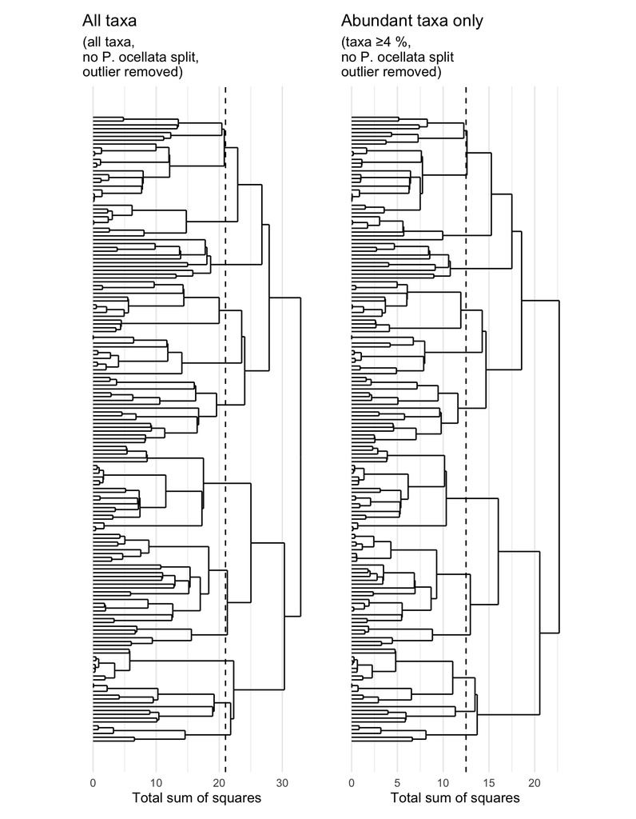

```r
# On taxa present at ≥4%
# ——————————————————————

# Prepare data
dist_matrix_ab_taxa <- taxa$rel_ab_4 %>%
  mutate(
    depth = imported$depths$depth,
    sample_no = NULL
  ) %>%
  column_to_rownames("depth") %>%
  filter(., rowSums(.) > 0) %>%
  `/`(100) %>%
  sqrt() %>%
  rownames_to_column("depth") %>%
  mutate(depth = as.numeric(depth)) %>%
  slice(., -44) %>%
  column_to_rownames("depth") %>%
  designdist(., method = "A+B-2*J", terms = "quadratic")

# Run cluster analysis
clusters_ab_taxa <- chclust(dist_matrix_ab_taxa, method = "coniss")

# Create plots
ddata_ab_taxa <- dendro_data(clusters_ab_taxa, type = "rectangle")
ab_taxa <- ggplot(segment(ddata_ab_taxa)) +
  geom_segment(aes(x = x, y = y, xend = xend, yend = yend)) +
  coord_flip() +
  scale_x_reverse(breaks = NULL,
                  labels = NULL) +
  labs(x = "",
       y = "Total sum of squares") +
  theme_minimal() +
  theme(aspect.ratio = 3)


# Plot dendrograms
# ————————————————
no_split +
  labs(
    title = "All taxa",
    subtitle = "(all taxa,\nno P. ocellata split,\noutlier removed)"
    ) +
ab_taxa +
  labs(
    title = "Abundant taxa only",
    subtitle = "(taxa ≥4 %,\nno P. ocellata split\noutlier removed)"
    ) +
    geom_hline(yintercept = 12.5,
               linetype = 2)
```

Performing the analysis on abundant taxa only does change the dendrogram quite a bit but mostly at the smaller splits. The zones can actually remain the same except for zones 2/3 (where some samples in the original zone 2 are moved into zone 3) and zones 11/12 (where some samples in the original zone 11 are moved into zone 12).

#### Compare broken stick

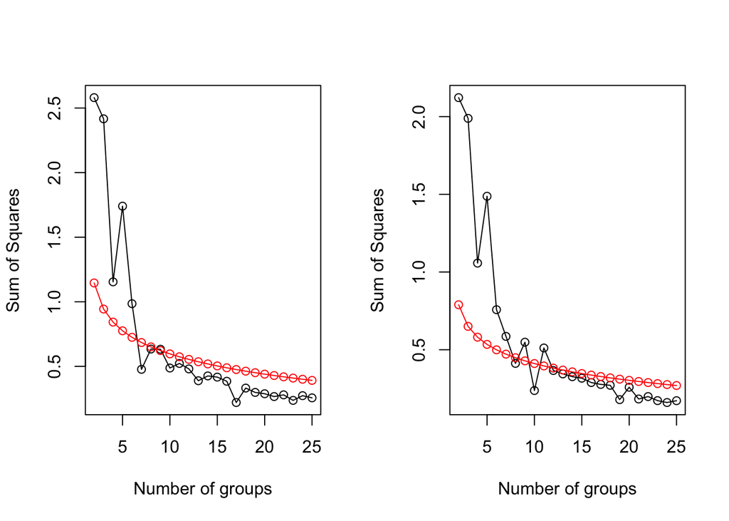

```r
par(mfrow = c(1, 2))
bstick(clusters_no_split, ng = 25)
bstick(clusters_ab_taxa, ng = 25)
```

The broken stick is a bit different here too. It becomes even more difficult to interpret with multiple fluctuations of the observed sum of squares above and below the model. It identifies between 7 and 11 zones.

#### Reassess zones

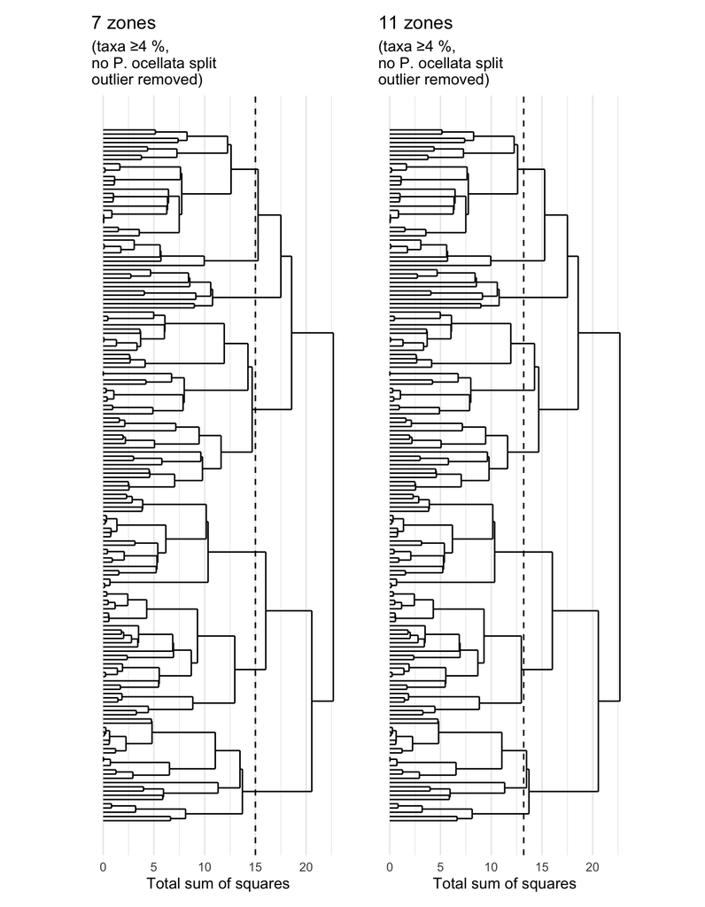

```r
ab_taxa +
  labs(
    title = "7 zones",
    subtitle = "(taxa ≥4 %,\nno P. ocellata split\noutlier removed)"
    ) +
  geom_hline(yintercept = 15,
             linetype = 2) +
ab_taxa +
  labs(
    title = "11 zones",
    subtitle = "(taxa ≥4 %,\nno P. ocellata split\noutlier removed)"
  ) +
  geom_hline(yintercept = 13.2,
             linetype = 2)
```

Forming 7 or 11 zones is actually quite difficult as for both there is only a very narrow area within which the straight line can be placed in order to split into those groups. 11 zones is clearly more similar to the original splits that I made on the dendrogram created with Tilia.

#### *Decision: use only abundant taxa*

### Decision 4: Should abundant taxa be those at ≥ 4 % or ≥ 5 %?

Gordon and Birks (1972) include taxa present at ≥5 % in at least one sample. As I am including taxa present at ≥4 % in at least one sample in my stratigraphic diagram, I thought it would be best that everything is consistent. I choose ≥4 % as this meant that *Asterionella formosa* was still included on the diagram, which could be very useful in interpretations. Displaying taxa present at ≥5 % meant this taxon was no longer displayed. The resulting stratigraphic diagram also displayed well when taxa present at ≥4 % were kept.

As I mentioned under my introduction paragraph of decision 3, Bennett (1996) explores the effect that changing the threshold for taxa inclusion has on the zonation and found there to be little effect.

#### Compare dendrograms

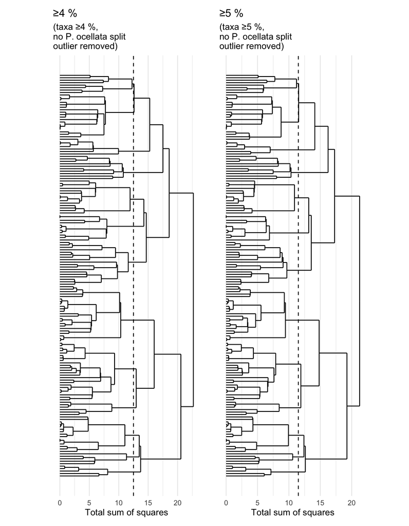

```r
# On taxa present at ≥5 %
# ———————————————————————

# Prepare data
taxa$rel_ab_5 <- taxa$rel_ab %>%
  transmute(
    sample_no = sample_no,
    select(., all_of(abundant_taxa(., 5)))
  )

dist_matrix_ab_taxa_5 <- taxa$rel_ab_5 %>%
  mutate(
    depth = imported$depths$depth,
    sample_no = NULL
  ) %>%
  column_to_rownames("depth") %>%
  filter(., rowSums(.) > 0) %>%
  `/`(100) %>%
  sqrt() %>%
  rownames_to_column("depth") %>%
  mutate(depth = as.numeric(depth)) %>%
  slice(., -44) %>%
  column_to_rownames("depth") %>%
  designdist(., method = "A+B-2*J", terms = "quadratic")

# Run cluster analysis
clusters_ab_taxa_5 <- chclust(dist_matrix_ab_taxa_5, method = "coniss")

# Create plots
ddata_ab_taxa_5 <- dendro_data(clusters_ab_taxa_5, type = "rectangle")
ab_taxa_5 <- ggplot(segment(ddata_ab_taxa_5)) +
  geom_segment(aes(x = x, y = y, xend = xend, yend = yend)) +
  coord_flip() +
  scale_x_reverse(breaks = NULL,
                  labels = NULL) +
  labs(x = "",
       y = "Total sum of squares") +
  theme_minimal() +
  theme(aspect.ratio = 3)


# Plot dendrograms
ab_taxa +
  labs(
    title = "≥4 %",
    subtitle = "(taxa ≥4 %,\nno P. ocellata split\noutlier removed)"
  ) +
  geom_hline(yintercept = 12.5,
             linetype = 2) +
ab_taxa_5 +
  labs(
    title = "≥5 %",
    subtitle = "(taxa ≥5 %,\nno P. ocellata split\noutlier removed)"
  ) +
  geom_hline(yintercept = 11.5,
             linetype = 2)
```

The resulting dendrograms are very similar. For the ≥5 % dendrogram, a shift of the verical line to the left results in the same zonation as for ≥4 % except for one sample in zone 11 of ≥4 %, which finds itself in zone 12 of ≥5 %.

#### Compare broken stick

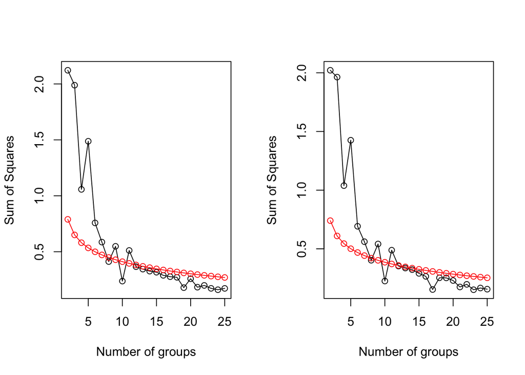

```r
par(mfrow = c(1, 2))
bstick(clusters_ab_taxa, ng = 25)
bstick(clusters_ab_taxa_5, ng = 25)
```

The broken stick is very similar for both. It is difficult to make out if it is after the 11th or 12th split that the observed sum of squares drops below the modelled sum of squares. Even a closer look shows it is very close:

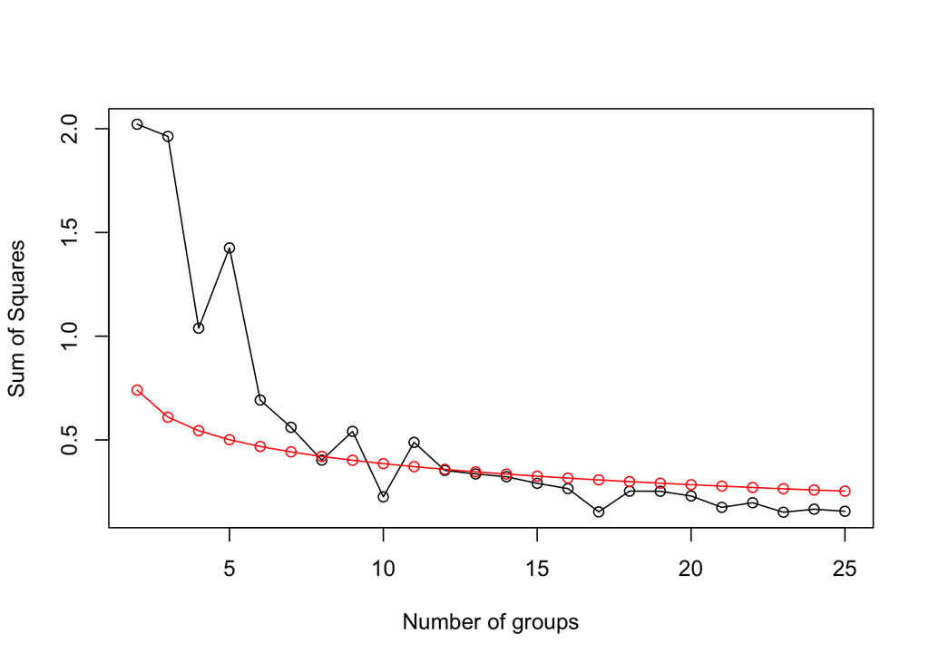

```r
bstick(clusters_ab_taxa_5, ng = 25)
```

#### *Decision: stick with ≥4 %*

### Decision 5: Should the % abundance be based on a sum of all taxa or abundant taxa?

My instinct was to calculate percentage abundances of a taxon out of all taxa that were counted in a sample. I didn’t even think of doing it another way until I read that Gordon & Birks (1972) calculated their percentages out of only the abundant taxa that they were using in their CONISS analysis. Every single paper I have come across has used their method, calculating percentage abundance of taxa based only on abundant taxa.

I am struggling with why this would be done but will have a go at guessing why — the taxa present at such low abundances are not statistically viable because they are potentially only there as a result of sampling chance. It could have been a fluke that a valve of a rare taxon fell on the part of the slide I was looking at rather than one of the more abundant taxa. Thus, the counts for the abundant taxa appear lower than they should have been. Or this might not be the case and the occurence of that rare taxon valve is representative of the original population. Either way there is an element of doubt due to such low counts (sometimes only one or two valves) that it statistically more robust to remove them.

### Compare dendrograms

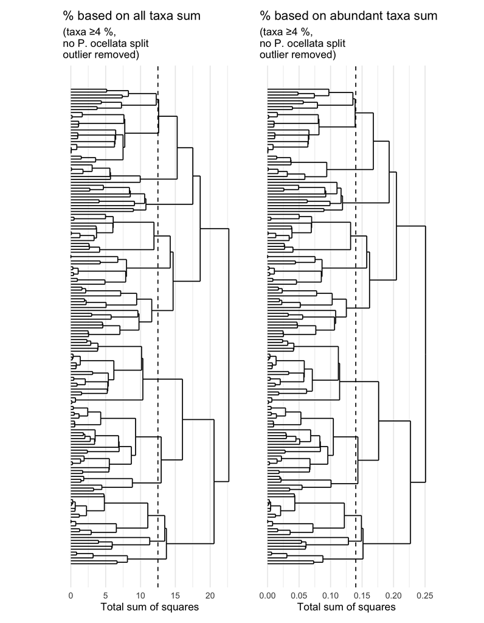

```r
# With percentages based on sum of abundant taxa
# ——————————————————————————————————————————————

# Prepare data
taxa$sum_ab_only <- taxa$counts %>%
  # isolate taxa present at ≥4 %
  transmute(
    sample_no = sample_no,
    select(., all_of(abundant_taxa(taxa$rel_ab, 4)))
  ) %>%
  # convert to proportion based on only these abundant taxa
  mutate(
    sample_no = sample_no,
    decostand(select(., -sample_no),
              method = "total",
              na.rm = "TRUE")
  )

dist_matrix_sum_ab_only <- taxa$sum_ab_only %>%
  mutate(
    depth = imported$depths$depth,
    sample_no = NULL
  ) %>%
  column_to_rownames("depth") %>%
  filter(., rowSums(.) > 0) %>%
  `/`(100) %>%
  sqrt() %>%
  rownames_to_column("depth") %>%
  mutate(depth = as.numeric(depth)) %>%
  slice(., -44) %>%
  column_to_rownames("depth") %>%
  designdist(., method = "A+B-2*J", terms = "quadratic")

# Run cluster analysis
clusters_sum_ab_only <- chclust(dist_matrix_sum_ab_only, method = "coniss")

# Create plot
ddata_sum_ab_only <- dendro_data(clusters_sum_ab_only, type = "rectangle")
sum_ab_only <- ggplot(segment(ddata_sum_ab_only)) +
  geom_segment(aes(x = x, y = y, xend = xend, yend = yend)) +
  coord_flip() +
  scale_x_reverse(breaks = NULL,
                  labels = NULL) +
  labs(x = "",
       y = "Total sum of squares") +
  theme_minimal() +
  theme(aspect.ratio = 3)

# Plot dendrograms
ab_taxa +
  labs(
    title = "% based on all taxa sum",
    subtitle = "(taxa ≥4 %,\nno P. ocellata split\noutlier removed)"
  ) +
  geom_hline(yintercept = 12.5,
             linetype = 2) +
sum_ab_only +
    labs(
    title = "% based on abundant taxa sum",
    subtitle = "(taxa ≥4 %,\nno P. ocellata split\noutlier removed)"
  ) +
  geom_hline(yintercept = 0.14,
             linetype = 2)
```

The dendograms look very similar. The most obvious difference is that the total sum of squares values on the x-axis have become very small! There are some minor differences at the low level splits (those that cluster towards the left side of the plot), but nothing that effects the zonation. If I calculate the distance matrix on percentages, rather than proportions out of 1, then the total sum of squares values go back to their usual span of 0 to around 20/30. These are nice whole numbers and look nicer that the awkward decimals on this latest plot. The absolute values for the total sum of squares doesn’t isn’t of any use to me and the only reason I converted to proportions was to replicate the Tilia analysis. So it might be best to not convert them to proportions out of 1. It is also nice that it means I can just stick with percentages for consistency.

#### Compare broken stick

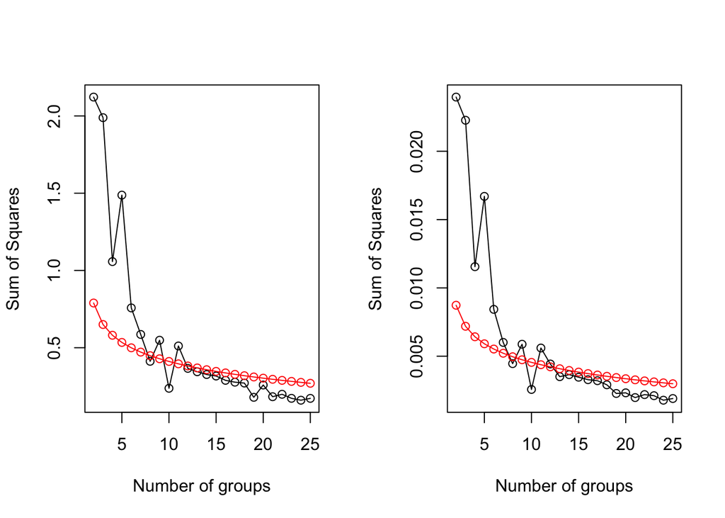

```r
par(mfrow = c(1, 2))
bstick(clusters_ab_taxa, ng = 25)
bstick(clusters_sum_ab_only, ng = 25)
```

The broken stick model for the percentages based on only the abundant taxa suggests there should be 12 zones rather than the 11 zones previously identified. This is the same number of zones that I had originally split the record into.

#### *Decision: base percentage calculations on sum of only abundant taxa*

## 5. Conclusion

After addressing all of my questions, this is the resulting CONISS analysis and zonation scheme that I have decided upon.

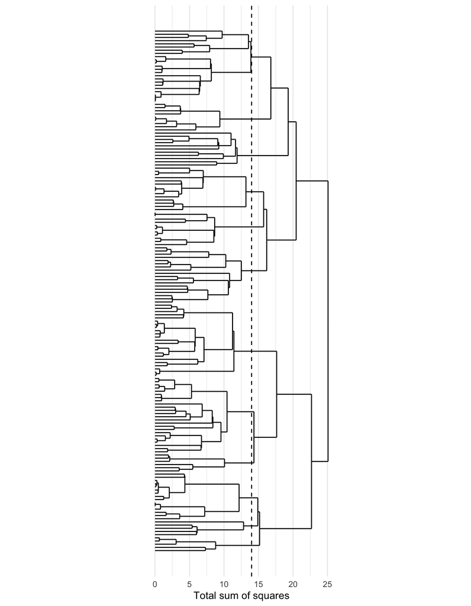

```r
# Recreate matrix but based on percentages rather than proportions out of 1.0
dist_matrix_sum_ab_only <- taxa$sum_ab_only %>%
  mutate(
    depth = imported$depths$depth,
    sample_no = NULL
  ) %>%
  column_to_rownames("depth") %>%
  filter(., rowSums(.) > 0) %>%
  sqrt() %>%
  rownames_to_column("depth") %>%
  mutate(depth = as.numeric(depth)) %>%
  slice(., -44) %>%
  column_to_rownames("depth") %>%
  designdist(., method = "A+B-2*J", terms = "quadratic")

# Run cluster analysis
clusters_sum_ab_only <- chclust(dist_matrix_sum_ab_only, method = "coniss")

# Create plot
ddata_sum_ab_only <- dendro_data(clusters_sum_ab_only, type = "rectangle")
ggplot(segment(ddata_sum_ab_only)) +
  geom_segment(aes(x = x, y = y, xend = xend, yend = yend)) +
  coord_flip() +
  scale_x_reverse(breaks = NULL,
                  labels = NULL) +
  labs(x = "",
       y = "Total sum of squares") +
  theme_minimal() +
  theme(aspect.ratio = 3) +
  geom_hline(yintercept = 14,
             linetype = 2)
```

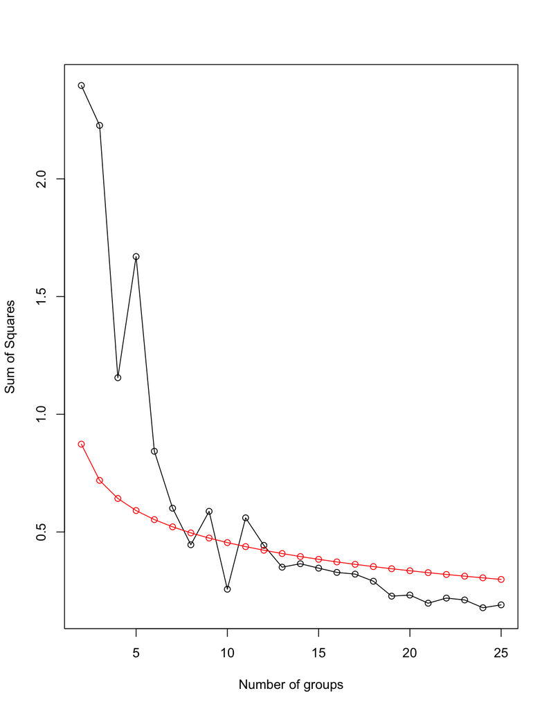

```r
bstick(clusters_sum_ab_only, ng = 25)
```

## References

Bennett, K. D. (1996) Determination of the number of zones in a biostratigraphical sequence. *New Phytologist*, 132, 155–170. https://doi.org/10.1111/j.1469-8137.1996.tb04521.x

Birks, H. J. B. (1986) Numerical zonation, comparison and correlation of Quaternary pollen-stratigraphical data. In Berglund, B. E. (ed) *Handbook of Palaeoecology and Palaeohydrology*. Chichester: John Wiley & Sons.

Birks, H. J. B. (2012) Analysis of stratigraphical data. In Birks, H. J. B., Lotter, A. F., Juggins, S. & Smol, J. P. (eds) *Tracking Environmental Change* *using Lake Sediments. Volume 5: Data Handling and Numerical Techniques*. Dordrecht: Springer. https://doi.org/10.1007/978-94-007-2745-8_11

Birks, H. J. B. & Berglund, B. E. (1979) Holocene pollen stratigraphy of southern Sweden: a reappraisal using numerical methods. *Boreas*, 8, 257–279. https://doi.org/10.1111/j.1502-3885.1979.tb00811.x

Birks, H. J. B. & Gordon, A. D. (1985) *Numerical methods in Quaternary pollen* *analysis*. London: Academic Press.

Gordon, A. D. & Birks, H. J. B. (1972) Numerical methods in Quaternary palaeoecology. I. Zonation of pollen diagrams. *New Phytologist*, 71, 961–979. https://doi.org/10.1111/j.1469-8137.1972.tb01976.x

Grimm, E. C. (1987) CONISS: A Fortran 77 program for stratigraphically constrained cluster analysis by the method of incremental sum of squares. *Computers & Geosciences*, 13, 13–35. https://doi.org/10.1016/0098-3004(87)90022-7

Grimm, E. C. (2011) *Tilia version 1.7.16* [Software]. Illinois State Museum, Springfield. https://www.tiliait.com